# PERÚ: DIEZ AÑOS DESPUÉS

[figure not shown]

[figure not shown]

[figure not shown]

[figure not shown]

[figure not shown]

[figure not shown]

[figure not shown]

[figure not shown]

[figure not shown]

# **CAMBIOS EN INDICADORES SOCIALES**

### **NOTAS**

- Niveles a la actualidad (2017 o el mayor año):
  - **Aceptable**: No más del 10% de la población cumple con la condición.
  - **Preocupante**: Entre el 10% y 25% de la población cumple con la condición.
  - **Alarmante**: Entre el 25% y 50% de la población cumple con la condición.
  - **Crítico**: Al menos el 50% de la población cumple con la condición.
- Avances: Es el resultado de la diferencia entre la cifra del indel 2017, o el mayor año, y la cifra del 2007, o el menor año, en puntos porcentuales.
  - **< -25**: La diferencia supera los 25 puntos porcentuales. Supone una importante mejora.
  - **-10 a -25**: La diferencia oscila entre los 10 y 25 puntos porcentuales.Supone una mejora intermedia.
  - **-10 a 0**: La diferencia oscila entre los 0 y 10 puntos porcentuales.Supone ningún cambio o una leve mejora.
  - **0 a 10**: La diferencia implica un leve retroceso de entre 1 y 10 puntos porcentuales.
  - **10 a 25**: La diferencia implica un retroceso intermedio de entre 10 y 25 puntos porcentuales.
  - **> 25**: La diferencia implica un importante retroceso, de - al menos - 25 puntos porcentuales.

### **Cobertura de los servicios de salud**

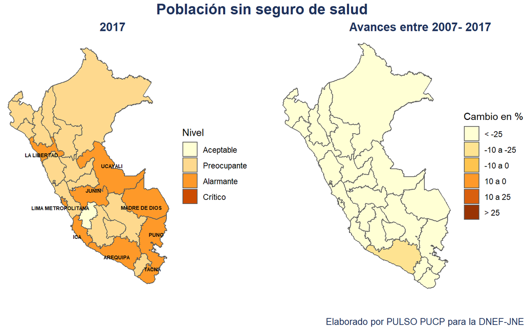

### **Trabajo decente**

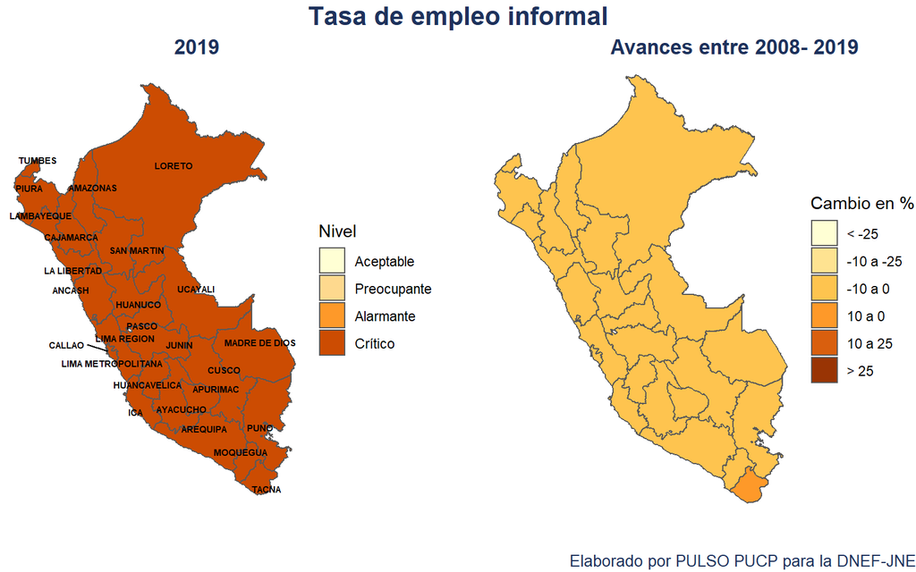

### **Alfabetización**

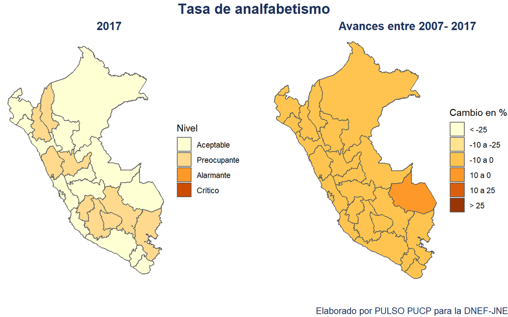

### **Datos utilizados**

- **Cobertura de los servicios de salud**
  - 2007: Censos Nacionales 2007: XI de Población y VI de Vivienda. Recuperado de http://censos.inei.gob.pe/Censos2007/redatam/
  - 2017: Censos Nacionales 2017: XII de Población, VII de Vivienda y III de Comunidades Indígenas. Recuperado de https://censos2017.inei.gob.pe/redatam/
- **Trabajo decente**
  - Perú: Evolución de los Indicadores de Empleo e Ingreso por Departamento, 2007-2019. Recuperado de https://www.inei.gob.pe/media/MenuRecursivo/publicaciones_digitales/Est/Lib1790/libro.pdf
- **Alfabetización**
  - Tasa de analfabetismo de la población de 15 y más años, según ámbito geográfico. Recuperado de https://www.inei.gob.pe/media/MenuRecursivo/publicaciones_digitales/Est/Lib1758/cap05/cap05057.xlsx

# **CAMBIOS EN INDICADORES DE VIVIENDA**

### **NOTAS**

- Niveles a la actualidad (2017 o el mayor año):
  - **Aceptable**: No más del 10% de la población cumple con la condición.
  - **Preocupante**: Entre el 10% y 25% de la población cumple con la condición.
  - **Alarmante**: Entre el 25% y 50% de la población cumple con la condición.
  - **Crítico**: Al menos el 50% de la población cumple con la condición.
- Avances: Es el resultado de la diferencia entre la cifra del indel 2017, o el mayor año, y la cifra del 2007, o el menor año, en puntos porcentuales.
  - **< -25**: La diferencia supera los 25 puntos porcentuales. Supone una importante mejora.
  - **-10 a -25**: La diferencia oscila entre los 10 y 25 puntos porcentuales.Supone una mejora intermedia.
  - **-10 a 0**: La diferencia oscila entre los 0 y 10 puntos porcentuales.Supone ningún cambio o una leve mejora.
  - **0 a 10**: La diferencia implica un leve retroceso de entre 1 y 10 puntos porcentuales.
  - **10 a 25**: La diferencia implica un retroceso intermedio de entre 10 y 25 puntos porcentuales.
  - **> 25**: La diferencia implica un importante retroceso, de - al menos - 25 puntos porcentuales.

### **Acceso a agua**

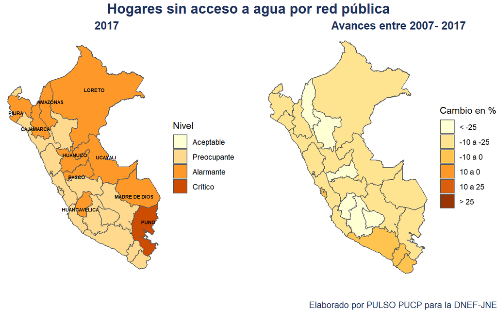

### **Acceso a servicios energéticos**

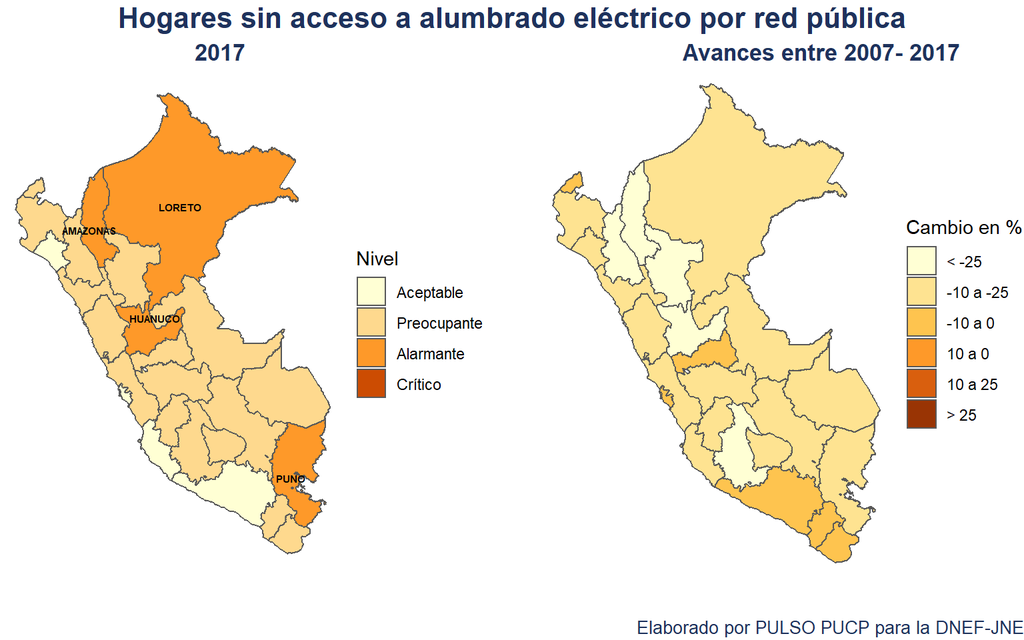

### **Tenencia de vivienda**

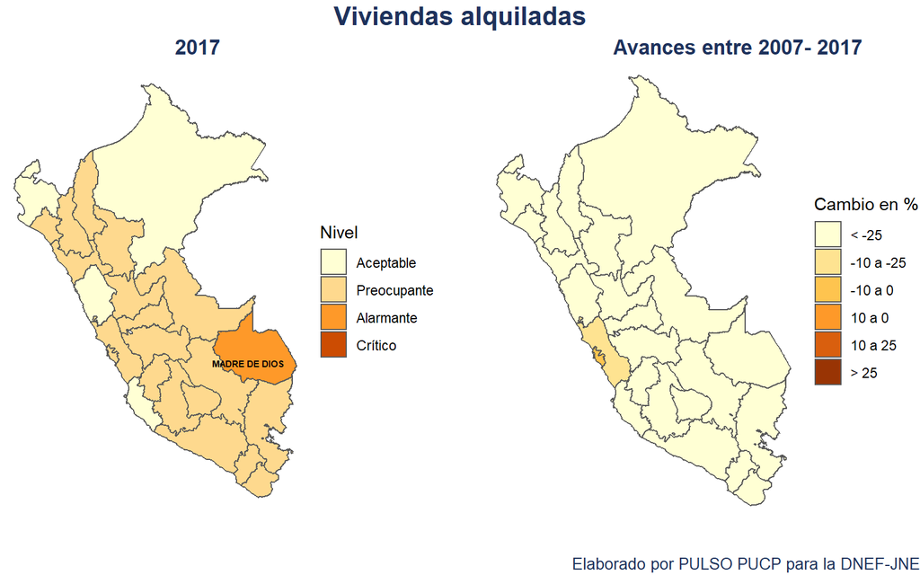

### **Datos utilizados**

- **Acceso a agua**
  - Perfil Sociodemográfico del Perú. Recuperado de https://www.inei.gob.pe/media/MenuRecursivo/publicaciones_digitales/Est/Lib1539/
- **Acceso a servicios energéticos**
  - Proporción de la población que tiene acceso a la electricidad. Recuperado de http://ods.inei.gob.pe/ods/objetivos-de-desarrollo-sostenible/energia-asequible-y-no-contaminante
- **Tenencia de vivienda**
  - 2007: Censos Nacionales 2007: XI de Población y VI de Vivienda. Recuperado de http://censos.inei.gob.pe/Censos2007/redatam/
  - 2017: Censos Nacionales 2017: XII de Población, VII de Vivienda y III de Comunidades Indígenas. Recuperado de https://censos2017.inei.gob.pe/redatam/

# **CAMBIOS EN INDICADORES DE HOGAR**

### **NOTAS**

- Niveles a la actualidad (2017 o el mayor año):
  - **Aceptable**: No más del 10% de la población cumple con la condición.
  - **Preocupante**: Entre el 10% y 25% de la población cumple con la condición.
  - **Alarmante**: Entre el 25% y 50% de la población cumple con la condición.
  - **Crítico**: Al menos el 50% de la población cumple con la condición.
- Avances: Es el resultado de la diferencia entre la cifra del indel 2017, o el mayor año, y la cifra del 2007, o el menor año, en puntos porcentuales.
  - **< -25**: La diferencia supera los 25 puntos porcentuales. Supone una importante mejora.
  - **-10 a -25**: La diferencia oscila entre los 10 y 25 puntos porcentuales.Supone una mejora intermedia.
  - **-10 a 0**: La diferencia oscila entre los 0 y 10 puntos porcentuales.Supone ningún cambio o una leve mejora.
  - **0 a 10**: La diferencia implica un leve retroceso de entre 1 y 10 puntos porcentuales.
  - **10 a 25**: La diferencia implica un retroceso intermedio de entre 10 y 25 puntos porcentuales.
  - **> 25**: La diferencia implica un importante retroceso, de - al menos - 25 puntos porcentuales.

### **Acceso a Tecnologías de la Información y Comunicaciones**

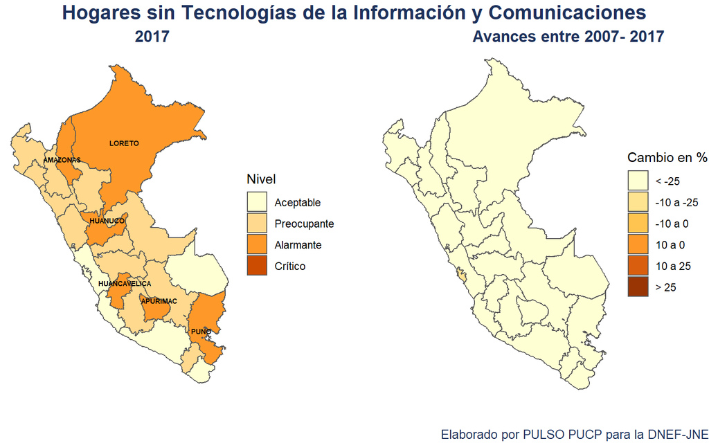

### **Acceso a servicios básicos**

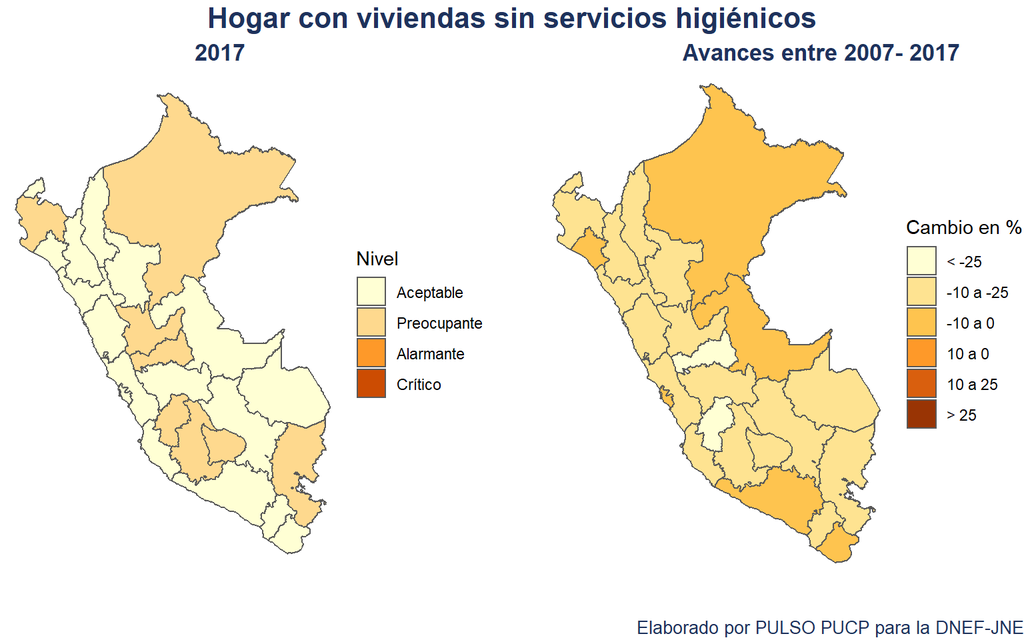

### **Acceso a vivienda adecuada**

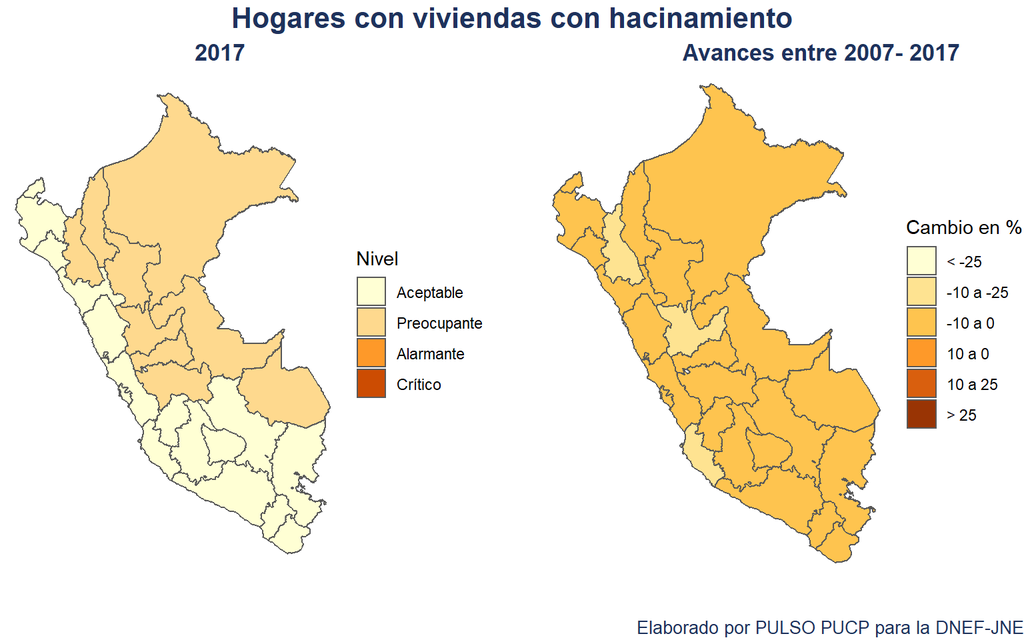

### **Datos utilizados**

- **Acceso a Tecnologías de la Información y Comunicaciones**
  - Perfil Sociodemográfico del Perú. Recuperado de https://www.inei.gob.pe/media/MenuRecursivo/publicaciones_digitales/Est/Lib1539/
- **Acceso a servicios básicos**
  - Perú: Mapa de Necesidades Básicas Insatisfechas, 1993, 2007 y 2017. Recuperado de https://www.inei.gob.pe/media/MenuRecursivo/publicaciones_digitales/Est/Lib1588/
- **Acceso a vivienda adecuada**
  - Perú: Mapa de Necesidades Básicas Insatisfechas, 1993, 2007 y 2017. Recuperado de https://www.inei.gob.pe/media/MenuRecursivo/publicaciones_digitales/Est/Lib1588/